# STAT 380 Final Project

An Analysis of Terrorism and Economics

Greg Westfall and TJ Schaeffer

```r
# clear environment
rm(list = ls())

# Packages
library(mdsr)
library(readr)
library(dplyr)
library(tidyr)
library(tidytext)
library(wordcloud)
library(readtext)
library(class)
library(tibble)
library(wordcloud)
library(randomForest)

# load data
data("stop_words")
```

First we must load the data sets. The terrorism data set takes some extra consideration due to its large size.

```r
# Reading in Terrorism
terrorism <- read.table(unz("globalterrorismdb_0718dist.csv.zip", "globalterrorismdb_0718dist.csv"), nrows=181692, header=T, fill =T, quote="\"", sep=",")
# Reading in Econ Data
econData <- read.csv("WEO_Data.csv")
```

Since the terrorism data set has too many columns to show, we will filter it down to information that we really care about. This is the number of attacks that each country has had.

```r
terrorism_deaths <-
  terrorism %>%
  group_by(country_txt) %>%
  summarise(attacks = n(), deaths = sum(na.omit(nkill))) %>%
  arrange(desc(deaths))
terrorism_deaths
```

| country_txt | attacks | deaths |
| --- | --- | --- |
| Iraq | 24636 | 78589 |
| Afghanistan | 12731 | 39384 |
| Pakistan | 14368 | 23818 |
| Nigeria | 3907 | 22682 |
| India | 11960 | 19341 |
| Sri Lanka | 3022 | 15530 |
| Syria | 2201 | 15229 |
| Colombia | 8306 | 14695 |
| Peru | 6096 | 12771 |
| El Salvador | 5320 | 12053 |

[output cut: 195 more lines]

Now we’ll look at some of the words associated with terrorist attacks to see if we can get a better idea of what we’re working with.

```r
terrorism_words <-
  terrorism %>%
  select(attacktype1_txt, weaptype1_txt, weapsubtype1_txt, weapdetail) %>%
  gather(key = type, value = input) %>%
  select(input)
```

```
attributes are not identical across measure variables;
they will be dropped
```

```r
terrorism_words <-
  terrorism_words %>%
  unnest_tokens(output = word, input = input)
terrorism_words %>%
  count(word, sort = TRUE)
```

| word | n |
| --- | --- |
| unknown | 110200 |
| explosives | 97982 |
| bombing | 88607 |
| explosion | 88326 |
| explosive | 86728 |
| type | 86101 |
| firearms | 65576 |
| attack | 58214 |
| the | 52746 |
| automatic | 51101 |

[output cut: 990 more lines]

Now we need to take out all of the “stop words,” words like the, a, an, and others.

```r
terrorism_words <-
  terrorism_words %>%
  filter(!(word %in% stop_words$word))

terrorism_words %>%
  count(word, sort = TRUE)
```

| word | n |
| --- | --- |
| unknown | 110200 |
| explosives | 97982 |
| bombing | 88607 |
| explosion | 88326 |
| explosive | 86728 |
| type | 86101 |
| firearms | 65576 |
| attack | 58214 |
| automatic | 51101 |
| assault | 44816 |

[output cut: 990 more lines]

Then we’ll make a word cloud showing what words are most used when describing terrorist attacks. We also don’t want “unknown” as part of it, so we take steps to get rid of that word.

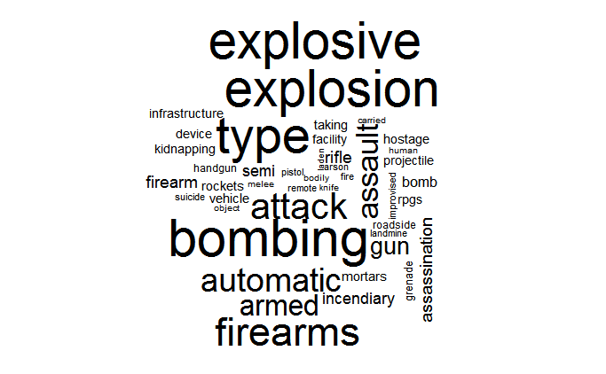

```r
terrorism_words %>%
  count(word) %>%
  filter(n < 100000) %>%
  with(., wordcloud(word, n, max.words = 45))
```

Moving past that, it is interesting to plot the coordinates of each terrorist attack to see where in the world a higher percentage of terrorist attacks occur. To avoid overplotting, we take a sample of 5000 random attacks. From this, we can see that a lot of attacks are clustered in the Middle East and India, Central and South America, and Southeast Asia.

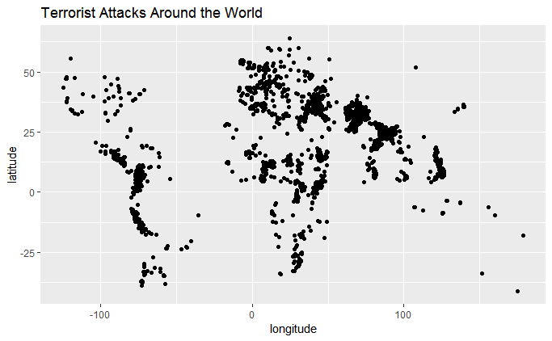

```r
terrorism %>%
  sample(5000) %>%
  ggplot(aes(x = longitude, y = latitude)) +
  geom_point() +
  ggtitle("Terrorist Attacks Around the World")
```

Now we just want to look at the 25 countries with the most terrorist attacks. To evaluate the similarity between them, we make a dendogram to look at their relationships. It tells us that Iraq is far and away an outlier in terms of attacks.

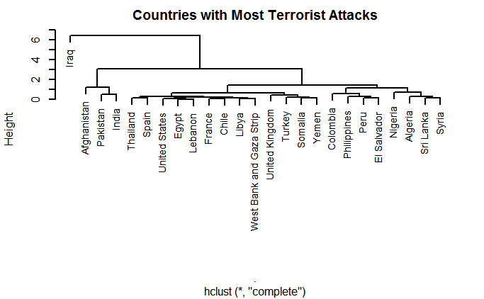

```r
td2 <- terrorism_deaths[-c(1)]
td2 <-
  td2 %>%
  select(attacks, deaths) %>%
  arrange(desc(attacks)) %>%
  head(25)
td_top_25 <-
  terrorism_deaths %>%
  arrange(desc(attacks)) %>%
  head(25)
td_std <-
  scale(td2) %>%
  as.data.frame()
td_dist <- dist(td_std)
td_dendo <-
  td_dist %>%
  hclust(method = "complete")
labels <- td_top_25$country_txt
td_dendo %>%
  plot(cex = 0.9, labels = labels, lwd = 2,
       main = "Countries with Most Terrorist Attacks")
```

Next we will examine how the number of terrorist attacks in the six countries with the most of them changed over time. This shows us that the number of attacks in most countries has spiked in recent years, although it was highest in Colombia in the 1980s and 90s.

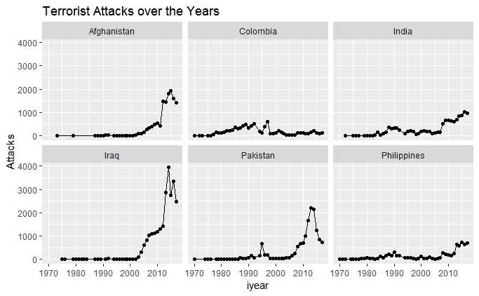

```r
Top_6_Countries <-
  terrorism %>%
  filter(country_txt == "Iraq" | country_txt == "Pakistan" |
         country_txt == "Afghanistan" | country_txt == "India" |
         country_txt == "Colombia" | country_txt == "Philippines") %>%
  group_by(country_txt, iyear) %>%
  summarise(Attacks = n())
Top_6_Countries %>%
  ggplot(aes(x = iyear, y = Attacks)) +
  geom_point() + geom_line() +
  facet_wrap(~country_txt) +
  ggtitle("Terrorist Attacks over the Years")
```

Looking specifically at the U.S., we can see that most terrorist attacks happen in coastal places, which happens to be where the most heavily populated cities are. We also wanted to examine which attacks were deadliest, so we filtered out the attacks of September 11, 2001 since they are outliers in terms of number of deaths. Even after doing this, one attack seems to have killed a lot more than the others. This happens to be the Oklahoma City bombing, which happened in 1995.

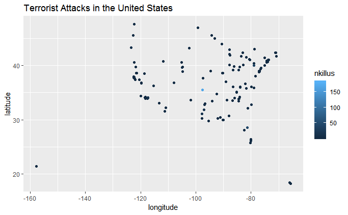

```r
terrorism %>%
  filter(country_txt == "United States") %>%
  filter(longitude < 0) %>%
  filter(nkillus > 0 & nkillus < 200) %>%
  ggplot(aes(x = longitude, y = latitude)) +
  geom_point(aes(color = nkillus)) +
  ggtitle("Terrorist Attacks in the United States")
```

Next, we want to look at our economic data in conjunction with the terrorism data to see if there are any indicators that we can use to look out for terrorism.

First, the values in the econ data frame are not numeric, so we will change that with the `apply` function. Then we’ll clean up the data a little bit.

```r
# Using apply to change values in data frame to numbers
econNumeric <- apply(X = econData[,5:30], FUN = as.numeric, MARGIN = 2)
```

[output not shown]

```r
econDataNew <-
  econData %>%
  select(c(1:4))

econData2 <-
  as.data.frame(econNumeric)
econDataNew <-
  econDataNew %>%
  cbind(econData2)
econDataNew
```

| Country | Subject.Descriptor | Units | Scale | X1999 | X2000 | X2001 | X2002 | X2003 | X2004 | X2005 | X2006 | X2007 | X2008 | X2009 | X2010 | X2011 | X2012 | X2013 | X2014 | X2015 | X2016 | X2017 | X2018 | X2019 | X2020 | X2021 | X2022 | X2023 | X2024 |
| --- | --- | --- | --- | --- | --- | --- | --- | --- | --- | --- | --- | --- | --- | --- | --- | --- | --- | --- | --- | --- | --- | --- | --- | --- | --- | --- | --- | --- | --- |
| Afghanistan | Gross domestic product, constant prices | Percent change |  | NA | NA | NA | NA | 8.692000e+00 | 6.710000e-01 | 1.183000e+01 | 5.361000e+00 | 1.334000e+01 | 3.863000e+00 | 2.058500e+01 | 8.438000e+00 | 6.479000e+00 | 1.396800e+01 | 5.683000e+00 | 2.697000e+00 | 9.880000e-01 | 2.164000e+00 | 2.665000e+00 | 2.300000e+00 | 3.000000e+00 | 3.500000e+00 | 3.997000e+00 | 4.495000e+00 | 4.992000e+00 | 5.489000e+00 |
| Afghanistan | Gross domestic product, deflator | Index |  | NA | NA | NA | 9.776500e+01 | 1.107060e+02 | 1.230630e+02 | 1.362880e+02 | 1.467000e+02 | 1.600050e+02 | 1.864910e+02 | 1.814670e+02 | 1.961540e+02 | 2.164320e+02 | 2.347280e+02 | 2.399930e+02 | 2.475450e+02 | 2.541440e+02 | 2.674000e+02 | 2.721250e+02 | 2.738450e+02 | 2.791300e+02 | 2.889260e+02 | 3.019430e+02 | 3.170530e+02 | 3.329130e+02 | 3.495590e+02 |
| Afghanistan | Gross domestic product per capita, constant prices | Purchasing power parity; 2011 international dollar | Units | NA | NA | NA | 1.026919e+03 | 1.072081e+03 | 1.038717e+03 | 1.122246e+03 | 1.146868e+03 | 1.251729e+03 | 1.267823e+03 | 1.490030e+03 | 1.570952e+03 | 1.621757e+03 | 1.788776e+03 | 1.828781e+03 | 1.819260e+03 | 1.783941e+03 | 1.774189e+03 | 1.776667e+03 | 1.792807e+03 | 1.821810e+03 | 1.860603e+03 | 1.908445e+03 | 1.967262e+03 | 2.037906e+03 | 2.121456e+03 |
| Afghanistan | Gross domestic product based on purchasing-power-parity (PPP) share of world total | Percent |  | NA | NA | NA | 3.400000e-02 | 3.600000e-02 | 3.400000e-02 | 3.700000e-02 | 3.700000e-02 | 3.900000e-02 | 4.000000e-02 | 4.800000e-02 | 5.000000e-02 | 5.100000e-02 | 5.600000e-02 | 5.700000e-02 | 5.700000e-02 | 5.600000e-02 | 5.500000e-02 | 5.400000e-02 | 5.400000e-02 | 5.400000e-02 | 5.400000e-02 | 5.400000e-02 | 5.400000e-02 | 5.500000e-02 | 5.600000e-02 |
| Afghanistan | Total investment | Percent of GDP |  | NA | NA | NA | 2.724300e+01 | 3.010300e+01 | 3.535400e+01 | 3.705100e+01 | 2.949200e+01 | 5.585600e+01 | 3.022600e+01 | 3.650700e+01 | 3.026900e+01 | 2.640700e+01 | 2.534000e+01 | 2.309300e+01 | 1.746000e+01 | 1.848100e+01 | 1.853300e+01 | 1.771700e+01 | 1.707600e+01 | 1.653900e+01 | 1.622800e+01 | 1.679500e+01 | 2.066200e+01 | 2.158500e+01 | 2.224000e+01 |
| Afghanistan | Gross national savings | Percent of GDP |  | NA | NA | NA | 6.115100e+01 | 5.971900e+01 | 7.257000e+01 | 6.727700e+01 | 5.033700e+01 | 1.192460e+02 | 6.399400e+01 | 7.809400e+01 | 5.969800e+01 | 5.298100e+01 | 3.620400e+01 | 2.336700e+01 | 2.321900e+01 | 2.134200e+01 | 2.572800e+01 | 2.246200e+01 | 2.185600e+01 | 1.752600e+01 | 1.744000e+01 | 1.775400e+01 | 2.042400e+01 | 2.052800e+01 | 2.054300e+01 |
| Afghanistan | Inflation, average consumer prices | Index |  | NA | NA | NA | 3.126300e+01 | 4.241300e+01 | 4.935100e+01 | 5.456600e+01 | 5.826900e+01 | 6.332700e+01 | 8.005700e+01 | 7.460400e+01 | 7.622900e+01 | 8.522700e+01 | 9.071700e+01 | 9.741700e+01 | 1.019700e+02 | 1.012960e+02 | 1.057360e+02 | 1.109980e+02 | 1.116930e+02 | 1.138150e+02 | 1.177990e+02 | 1.230990e+02 | 1.292540e+02 | 1.357170e+02 | 1.425030e+02 |
| Afghanistan | Inflation, average consumer prices | Percent change |  | NA | NA | NA | NA | 3.566300e+01 | 1.635800e+01 | 1.056900e+01 | 6.785000e+00 | 8.681000e+00 | 2.641900e+01 | -6.811000e+00 | 2.179000e+00 | 1.180400e+01 | 6.441000e+00 | 7.386000e+00 | 4.674000e+00 | -6.620000e-01 | 4.384000e+00 | 4.976000e+00 | 6.260000e-01 | 1.900000e+00 | 3.500000e+00 | 4.500000e+00 | 5.000000e+00 | 5.000000e+00 | 5.000000e+00 |
| Afghanistan | Volume of imports of goods and services | Percent change |  | NA | NA | NA | NA | 3.458500e+01 | 8.440000e-01 | 5.666200e+01 | -1.924000e+00 | -9.622000e+00 | -8.186000e+00 | 2.851300e+01 | 3.425800e+01 | 1.234900e+01 | 3.069700e+01 | 5.177000e+00 | -1.589600e+01 | 1.556200e+01 | -8.126000e+00 | 3.298000e+00 | -1.111000e+00 | 3.751000e+00 | -2.060000e-01 | 9.690000e-01 | 5.471000e+00 | 2.403000e+00 | 1.440000e+00 |
| Afghanistan | Volume of Imports of goods | Percent change |  | NA | NA | NA | NA | 3.382800e+01 | -1.249000e+00 | 5.361200e+01 | -1.810000e-01 | -1.499200e+01 | -4.067000e+00 | 2.622100e+01 | 3.628500e+01 | 7.088000e+00 | 3.511300e+01 | 8.807000e+00 | -1.626100e+01 | 2.429200e+01 | -7.351000e+00 | 7.700000e-01 | -1.972000e+00 | 3.344000e+00 | -6.520000e-01 | 3.820000e-01 | 4.855000e+00 | 1.684000e+00 | 1.975000e+00 |

[output cut: 990 more lines]

In order to work with the data, it would be a lot easier to have a large number of rows instead of columns. We’ll use `gather` to accomplish this.

```r
# Using gather function to make data frame tidy
econDataTidy <-
  econDataNew %>%
  gather(key = "Year", value = "Value", 5:30)
econDataTidy
```

| Country | Subject.Descriptor | Units | Scale | Year | Value |
| --- | --- | --- | --- | --- | --- |
| Afghanistan | Gross domestic product, constant prices | Percent change |  | X1999 | NA |
| Afghanistan | Gross domestic product, deflator | Index |  | X1999 | NA |
| Afghanistan | Gross domestic product per capita, constant prices | Purchasing power parity; 2011 international dollar | Units | X1999 | NA |
| Afghanistan | Gross domestic product based on purchasing-power-parity (PPP) share of world total | Percent |  | X1999 | NA |
| Afghanistan | Total investment | Percent of GDP |  | X1999 | NA |
| Afghanistan | Gross national savings | Percent of GDP |  | X1999 | NA |
| Afghanistan | Inflation, average consumer prices | Index |  | X1999 | NA |
| Afghanistan | Inflation, average consumer prices | Percent change |  | X1999 | NA |
| Afghanistan | Volume of imports of goods and services | Percent change |  | X1999 | NA |
| Afghanistan | Volume of Imports of goods | Percent change |  | X1999 | NA |

[output cut: 990 more lines]

```r
# Creating average of values over the 26 years found in the data frame
econAverages <-
  econDataTidy %>%
  group_by(Country, Subject.Descriptor, Units) %>%
  summarise(average = mean(na.omit(Value)))
econAverages
```

| Country | Subject.Descriptor | Units | average |
| --- | --- | --- | --- |
|  |  |  | NaN |
| Afghanistan | Current account balance | Percent of GDP | 1.666109e+01 |
| Afghanistan | Current account balance | U.S. dollars | 1.670217e+00 |
| Afghanistan | General government gross debt | Percent of GDP | 5.476148e+01 |
| Afghanistan | General government net lending/borrowing | Percent of GDP | -7.324348e-01 |
| Afghanistan | General government primary net lending/borrowing | Percent of GDP | -6.491429e-01 |
| Afghanistan | General government revenue | Percent of GDP | 2.263261e+01 |
| Afghanistan | General government total expenditure | Percent of GDP | 2.336496e+01 |
| Afghanistan | Gross domestic product based on purchasing-power-parity (PPP) share of world total | Percent | 4.878261e-02 |
| Afghanistan | Gross domestic product corresponding to fiscal year, current prices | National currency | 1.052577e+03 |

[output cut: 990 more lines]

Since we want to look at the effects of several different predictors, it will be easiest to create a function to help us out.

```r
# User-defined function to create data frame based off subject indicator
create_deaths_table <- function(x, y){
  econAverages %>%
    filter(Subject.Descriptor == x, Units == y) %>%
    rename("country_txt" = "Country") %>%
    left_join(terrorism_deaths, by = "country_txt") %>%
    filter(!is.na(attacks) & !is.na(deaths)) %>%
    rename("Country" = "country_txt") %>%
    mutate(above_below = ifelse(attacks >= 1073.441, "above", "below"))
}
```

First we’ll look at how a country’s population affects number of terrorist attacks.

```r
# Data frame with population and attacks/deaths
PopDeaths <- create_deaths_table("Population", "Persons")
```

```
Column `country_txt` joining factors with different levels, coercing to character vector
```

```r
PopDeaths
```

| Country | Subject.Descriptor | Units | average | attacks | deaths | above_below |
| --- | --- | --- | --- | --- | --- | --- |
| Afghanistan | Population | Persons | 3.139296e+01 | 12731 | 39384 | above |
| Albania | Population | Persons | 2.937846e+00 | 80 | 42 | below |
| Algeria | Population | Persons | 3.777804e+01 | 2743 | 11066 | above |
| Angola | Population | Persons | 2.468435e+01 | 499 | 3043 | below |
| Antigua and Barbuda | Population | Persons | 8.615385e-02 | 1 | 0 | below |
| Argentina | Population | Persons | 4.164065e+01 | 815 | 490 | below |
| Armenia | Population | Persons | 3.003231e+00 | 24 | 37 | below |
| Australia | Population | Persons | 2.287404e+01 | 114 | 23 | below |
| Austria | Population | Persons | 8.525923e+00 | 115 | 30 | below |
| Azerbaijan | Population | Persons | 9.219654e+00 | 49 | 258 | below |

[output cut: 151 more lines]

The linear regression model tells us that population is a significant predictor in the number of terrorist attacks a country experiences.

```r
# logistic regression
pop_logit <- lm(attacks ~ average, data = PopDeaths)
msummary(pop_logit)
```

```
            Estimate Std. Error t value Pr(>|t|)
(Intercept)  858.180    227.085   3.779 0.000222 ***
average        5.144      1.487   3.460 0.000695 ***

Residual standard error: 2771 on 159 degrees of freedom
Multiple R-squared:  0.07001,   Adjusted R-squared:  0.06416
F-statistic: 11.97 on 1 and 159 DF,  p-value: 0.0006946
```

The predictive model is also very accurate, with it predicting successfully whether or not a country has an above average number of terrorist attacks based off of their population 83.2% of the time.

```r
# logistic confusion matrix
pop_logitProb <- predict(pop_logit, newdata = PopDeaths, type = "response")
pop_logit <- ifelse(pop_logitProb > mean(PopDeaths$attacks), yes = "above", "below")
confusion_logit_pop <- tally(pop_logit ~ above_below, data = PopDeaths,
                             format = "count")
confusion_logit_pop
```

```
         above_below
pop_logit above below
    above    17    11
    below    16   117
```

```r
# model accuracy
pop_logit_acc <- sum(diag(confusion_logit_pop)) / nrow(PopDeaths) * 100
pop_logit_acc
```

```
[1] 83.22981
```

Next we’ll see it per capita GDP has any relevance to terrorist attacks.

```r
# Data frame with GDP
GDPDeaths <- create_deaths_table("Gross domestic product per capita, constant prices",
                                 "Purchasing power parity; 2011 international dollar")
```

```
Column `country_txt` joining factors with different levels, coercing to character vector
```

```r
GDPDeaths
```

| Country | Subject.Descriptor | Units | average | attacks | deaths | above_below |
| --- | --- | --- | --- | --- | --- | --- |
| Afghanistan | Gross domestic product per capita, constant prices | Purchasing power parity; 2011 international dollar | 1603.9576 | 12731 | 39384 | above |
| Albania | Gross domestic product per capita, constant prices | Purchasing power parity; 2011 international dollar | 9712.2473 | 80 | 42 | below |
| Algeria | Gross domestic product per capita, constant prices | Purchasing power parity; 2011 international dollar | 12755.7275 | 2743 | 11066 | above |
| Angola | Gross domestic product per capita, constant prices | Purchasing power parity; 2011 international dollar | 5706.5584 | 499 | 3043 | below |
| Antigua and Barbuda | Gross domestic product per capita, constant prices | Purchasing power parity; 2011 international dollar | 23361.3511 | 1 | 0 | below |
| Argentina | Gross domestic product per capita, constant prices | Purchasing power parity; 2011 international dollar | 17539.7903 | 815 | 490 | below |
| Armenia | Gross domestic product per capita, constant prices | Purchasing power parity; 2011 international dollar | 7157.6930 | 24 | 37 | below |
| Australia | Gross domestic product per capita, constant prices | Purchasing power parity; 2011 international dollar | 43230.9661 | 114 | 23 | below |
| Austria | Gross domestic product per capita, constant prices | Purchasing power parity; 2011 international dollar | 43917.1319 | 115 | 30 | below |
| Azerbaijan | Gross domestic product per capita, constant prices | Purchasing power parity; 2011 international dollar | 13182.7860 | 49 | 258 | below |

[output cut: 151 more lines]

The regression model tells us that per capita GDP is not a significant predictor.

```r
# logistic regression
gdp_logit <- lm(attacks ~ average, data = GDPDeaths)
msummary(gdp_logit)
```

```
              Estimate Std. Error t value Pr(>|t|)
(Intercept) 1314.05779  306.20950   4.291 3.07e-05 ***
average       -0.01380    0.01188  -1.162    0.247

Residual standard error: 2861 on 159 degrees of freedom
Multiple R-squared:  0.008415,  Adjusted R-squared:  0.002178
F-statistic: 1.349 on 1 and 159 DF,  p-value: 0.2471
```

Additionally, the predictive model is only correct 41% of the time, which is worse than guessing.

```r
# logistic confusion matrix
gdp_logitProb <- predict(gdp_logit, newdata = GDPDeaths, type = "response")
gdp_logit <- ifelse(gdp_logitProb > mean(GDPDeaths$attacks), yes = "above", "below")
confusion_logit_gdp <- tally(gdp_logit ~ above_below, data = GDPDeaths,
                             format = "count")
confusion_logit_gdp
```

```
         above_below
gdp_logit above below
    above    22    84
    below    11    44
```

```r
# model accuracy
gdp_logit_acc <- sum(diag(confusion_logit_gdp)) / nrow(GDPDeaths) * 100
gdp_logit_acc
```

```
[1] 40.99379
```

Now we’ll see if inflation has any bearing on terrorist attacks.

```r
# Data Frame with inflation
InflationDeaths <- create_deaths_table("Inflation, average consumer prices",
                                       "Index")
```

```
Column `country_txt` joining factors with different levels, coercing to character vector
```

```r
InflationDeaths
```

| Country | Subject.Descriptor | Units | average | attacks | deaths | above_below |
| --- | --- | --- | --- | --- | --- | --- |
| Afghanistan | Inflation, average consumer prices | Index | 9.118783e+01 | 12731 | 39384 | above |
| Albania | Inflation, average consumer prices | Index | 9.262658e+01 | 80 | 42 | below |
| Algeria | Inflation, average consumer prices | Index | 1.667817e+02 | 2743 | 11066 | above |
| Angola | Inflation, average consumer prices | Index | 1.730066e+02 | 499 | 3043 | below |
| Antigua and Barbuda | Inflation, average consumer prices | Index | 1.256227e+02 | 1 | 0 | below |
| Argentina | Inflation, average consumer prices | Index | 2.116491e+02 | 815 | 490 | below |
| Armenia | Inflation, average consumer prices | Index | 2.367857e+02 | 24 | 37 | below |
| Australia | Inflation, average consumer prices | Index | 9.916258e+01 | 114 | 23 | below |
| Austria | Inflation, average consumer prices | Index | 1.147191e+02 | 115 | 30 | below |
| Azerbaijan | Inflation, average consumer prices | Index | 1.756252e+02 | 49 | 258 | below |

[output cut: 151 more lines]

Unfortunately, inflation is not a significant predictor either.

```r
# logistic regression
inflation_logit <- lm(attacks ~ average, data = InflationDeaths)
msummary(inflation_logit)
```

```
              Estimate Std. Error t value Pr(>|t|)
(Intercept)  1.078e+03  2.271e+02   4.748 4.56e-06 ***
average     -7.557e-35  2.773e-34  -0.273    0.786

Residual standard error: 2873 on 159 degrees of freedom
Multiple R-squared:  0.0004668, Adjusted R-squared:  -0.00582
F-statistic: 0.07426 on 1 and 159 DF,  p-value: 0.7856
```

The inflation predictive model is also the worst one we’ve seen so far, being correct only 21.1% of the time.

```r
# logistic confusion matrix
inflation_logitProb <- predict(inflation_logit, newdata = InflationDeaths,
                               type = "response")
inflation_logit <- ifelse(inflation_logitProb > mean(InflationDeaths$attacks),
                          yes = "above", "below")
confusion_logit_inflation <- tally(inflation_logit ~ above_below,
                                   data = InflationDeaths, format = "count")
confusion_logit_inflation
```

```
               above_below
inflation_logit above below
          above    33   127
          below     0     1
```

```r
# model accuracy
inflation_logit_acc <- sum(diag(confusion_logit_inflation)) /
                           nrow(InflationDeaths) * 100
inflation_logit_acc
```

```
[1] 21.11801
```

Now we’ll look at whether a country’s total government expenditure as a percent of their GDP has any impact.

```r
# Data frame involving total country spending
SpendingDeaths <- create_deaths_table("General government total expenditure",
                                      "Percent of GDP")
```

```
Column `country_txt` joining factors with different levels, coercing to character vector
```

```r
SpendingDeaths
```

| Country | Subject.Descriptor | Units | average | attacks | deaths | above_below |
| --- | --- | --- | --- | --- | --- | --- |
| Afghanistan | General government total expenditure | Percent of GDP | 23.36496 | 12731 | 39384 | above |
| Albania | General government total expenditure | Percent of GDP | 30.17485 | 80 | 42 | below |
| Algeria | General government total expenditure | Percent of GDP | 34.59312 | 2743 | 11066 | above |
| Angola | General government total expenditure | Percent of GDP | 31.22938 | 499 | 3043 | below |
| Antigua and Barbuda | General government total expenditure | Percent of GDP | 24.82869 | 1 | 0 | below |
| Argentina | General government total expenditure | Percent of GDP | 32.88273 | 815 | 490 | below |
| Armenia | General government total expenditure | Percent of GDP | 24.23140 | 24 | 37 | below |
| Australia | General government total expenditure | Percent of GDP | 36.02662 | 114 | 23 | below |
| Austria | General government total expenditure | Percent of GDP | 50.40762 | 115 | 30 | below |
| Azerbaijan | General government total expenditure | Percent of GDP | 29.71150 | 49 | 258 | below |

[output cut: 151 more lines]

Once again, the regression model shows no significance.

```r
# logistic regression
spending_logit <- lm(attacks ~ average, data = SpendingDeaths)
msummary(spending_logit)
```

```
             Estimate Std. Error t value Pr(>|t|)
(Intercept) 1083.2777   707.9632   1.530    0.128
average       -0.3209    21.8846  -0.015    0.988

Residual standard error: 2874 on 159 degrees of freedom
Multiple R-squared:  1.353e-06, Adjusted R-squared:  -0.006288
F-statistic: 0.0002151 on 1 and 159 DF,  p-value: 0.9883
```

The predictive model is also middle-of-the-road, as it is correct 49.1% of the time.

```r
# logistic confusion matrix
spending_logitProb <- predict(spending_logit, newdata = SpendingDeaths,
                              type = "response")
spending_logit <- ifelse(spending_logitProb > mean(SpendingDeaths$attacks),
                         yes = "above", "below")
confusion_logit_spending <- tally(spending_logit ~ above_below, data = SpendingDeaths,
                                  format = "count")
confusion_logit_spending
```

```
              above_below
spending_logit above below
         above    19    68
         below    14    60
```

```r
# model accuracy
spending_logit_acc <- sum(diag(confusion_logit_spending)) / nrow(SpendingDeaths) * 100
spending_logit_acc
```

```
[1] 49.06832
```

Finally, we’ll see if a country’s volume of imports has any effects.

```r
# Data frame involving percent change in imported goods and services
ImportDeaths <- create_deaths_table("Volume of imports of goods and services",
                                    "Percent change")
```

```
Column `country_txt` joining factors with different levels, coercing to character vector
```

```r
ImportDeaths
```

| Country | Subject.Descriptor | Units | average | attacks | deaths | above_below |
| --- | --- | --- | --- | --- | --- | --- |
| Afghanistan | Volume of imports of goods and services | Percent change | 8.677636 | 12731 | 39384 | above |
| Albania | Volume of imports of goods and services | Percent change | 6.367615 | 80 | 42 | below |
| Algeria | Volume of imports of goods and services | Percent change | 4.497346 | 2743 | 11066 | above |
| Angola | Volume of imports of goods and services | Percent change | 6.989462 | 499 | 3043 | below |
| Antigua and Barbuda | Volume of imports of goods and services | Percent change | 4.573800 | 1 | 0 | below |
| Argentina | Volume of imports of goods and services | Percent change | 5.877615 | 815 | 490 | below |
| Armenia | Volume of imports of goods and services | Percent change | 6.949769 | 24 | 37 | below |
| Australia | Volume of imports of goods and services | Percent change | 5.392192 | 114 | 23 | below |
| Austria | Volume of imports of goods and services | Percent change | 3.379692 | 115 | 30 | below |
| Azerbaijan | Volume of imports of goods and services | Percent change | 2.917885 | 49 | 258 | below |

[output cut: 145 more lines]

The regression model tells us once again that volume of imports is not a significant predictor.

```r
# logistic regression
import_logit <- lm(attacks ~ average, data = ImportDeaths)
msummary(import_logit)
```

```
            Estimate Std. Error t value Pr(>|t|)
(Intercept)  980.612    385.085   2.546   0.0119 *
average       -5.906     58.252  -0.101   0.9194

Residual standard error: 2216 on 153 degrees of freedom
Multiple R-squared:  6.719e-05, Adjusted R-squared:  -0.006468
F-statistic: 0.01028 on 1 and 153 DF,  p-value: 0.9194
```

Although volume of imports is not significant, the predictive model managed to crack the 50% barrier (52.25% to be exact), making it the second most accurate out of the ones we created.

```r
# logistic confusion matrix
import_logitProb <- predict(import_logit, newdata = ImportDeaths, type = "response")
import_logit <- ifelse(import_logitProb > mean(ImportDeaths$attacks),
                       yes = "above", "below")
confusion_logit_import <- tally(import_logit ~ above_below, data = ImportDeaths,
                             format = "count")
confusion_logit_import
```

```
            above_below
import_logit above below
       above    22    65
       below     9    59
```

```r
# model accuracy
import_logit_acc <- sum(diag(confusion_logit_import)) / nrow(ImportDeaths) * 100
import_logit_acc
```

```
[1] 52.25806
```

Our supervised learning showed us that out of all the predictors we looked at, the only one that has any real bearing on a country’s number of terrorist attacks is their population. Unfortunately, there’s not much we can advise to do to change this, so countries with larger populations must live with the increased risk of experiencing terrorist attacks.

To see if this holds true on a larger scale, we can plot the world population over time along with the number of global of terrorist attacks over the past 20 years. As expected, the number of terrorist attacks has increased as the world population has. However, the number of terrorist attacks fluctuates much more wildly than the global population. Maybe we could examine why this is so in future projects.

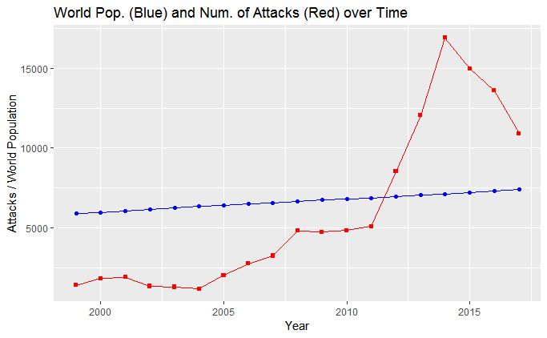

```r
YearEconData <-
  econDataTidy %>%
  filter(Subject.Descriptor == "Population")
year_terrorism_deaths <-
  terrorism %>%
  group_by(iyear) %>%
  filter(iyear >= 1999) %>%
  summarise(attacks = n(), deaths = sum(na.omit(nkill))) %>%
  rename("Year" = "iyear") %>%
  arrange(Year)
YearEconDataClean <-
  YearEconData %>%
  mutate(Year = as.numeric(gsub("X", "", Year))) %>%
  group_by(Year) %>%
  filter(Year <= 2017) %>%
  summarise(worldPop = sum(na.omit(Value)))
ggplot(data = year_terrorism_deaths, aes(x = Year, y = attacks)) +
  geom_point(color = "red", shape = 15) + geom_line(color = "red") +
  geom_point(aes(x = Year, y = worldPop), color = "blue", data = YearEconDataClean) +
  geom_line(aes(x = Year, y = worldPop), color = "blue", data = YearEconDataClean) +
  ylab("Attacks / World Population") +
  ggtitle("World Pop. (Blue) and Num. of Attacks (Red) over Time")
```